# examples_0521

Consider the string of characters shown below:

`CXRVGTQYC`

What new string would be created if every instance of `C` was replaced with `MF`?

(Please use all uppercase letters and NO spaces.)

Here is the answer:

MFXRVGTQYMF

Notice, every `C` is now `MF`.

Consider the string of characters shown below:

`WUDCTXWWZ`

What new string would be created if every instance of `W` was replaced with `PA`?

(Please use all uppercase letters and NO spaces.)

Here is the answer:

PAUDCTXPAPAZ

Notice, every `W` is now `PA`.

Consider the string of characters shown below:

`SYDKDYY`

What new string would be created if every instance of `Y` was replaced with `AL`?

(Please use all uppercase letters and NO spaces.)

Here is the answer:

SALDKDALAL

Notice, every `Y` is now `AL`.

Consider the string of characters shown below:

`FWYFTWWL`

What new string would be created if every instance of `W` was replaced with `UL`?

(Please use all uppercase letters and NO spaces.)

Here is the answer:

FULYFTULULL

Notice, every `W` is now `UL`.

Consider the string of characters shown below:

`DFDQND`

What new string would be created if every instance of `D` was replaced with `IF`?

(Please use all uppercase letters and NO spaces.)

Here is the answer:

IFFIFQNIF

Notice, every `D` is now `IF`.

Consider the string of characters shown below:

`XRJWXQRG`

What new string would be created if every instance of `X` was replaced with `MG`?

(Please use all uppercase letters and NO spaces.)

Here is the answer:

MGRJWMGQRG

Notice, every `X` is now `MG`.

Consider the string of characters shown below:

`ZYWNVAZ`

What new string would be created if every instance of `Z` was replaced with `GV`?

(Please use all uppercase letters and NO spaces.)

Here is the answer:

GVYWNVAGV

Notice, every `Z` is now `GV`.

Consider the string of characters shown below:

`ELPFDLF`

What new string would be created if every instance of `F` was replaced with `TA`?

(Please use all uppercase letters and NO spaces.)

Here is the answer:

ELPTADLTA

Notice, every `F` is now `TA`.

Consider the string of characters shown below:

`HGHZSXMZ`

What new string would be created if every instance of `H` was replaced with `YE`?

(Please use all uppercase letters and NO spaces.)

Here is the answer:

YEGYEZSXMZ

Notice, every `H` is now `YE`.

Consider the string of characters shown below:

`TUKKKC`

What new string would be created if every instance of `K` was replaced with `LY`?

(Please use all uppercase letters and NO spaces.)

Here is the answer:

TULYLYLYC

Notice, every `K` is now `LY`.

A turtle starts at the star in the middle, facing North. While dragging markers, she walks forward for a while, then turns either to her right (clockwise) or to her left (counterclockwise) by 90°. She repeats this, starting with a red marker, until she has drawn 4 segments.

The distance between adjacent dots is 1 unit.

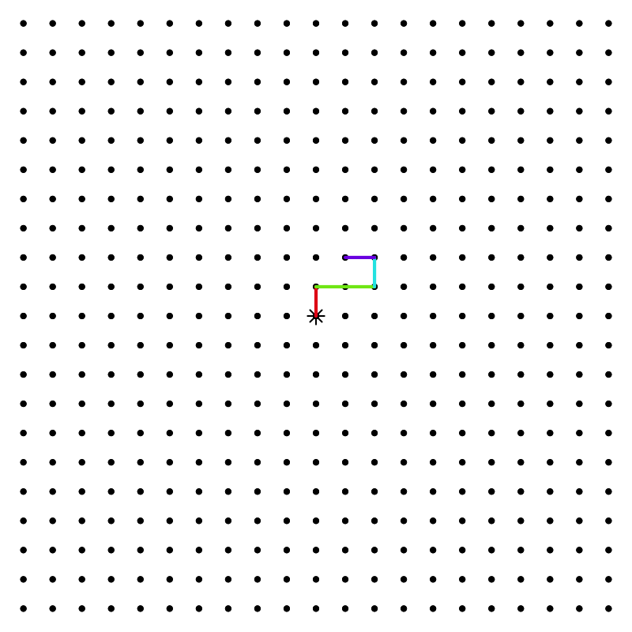

Describe the path taken by the turtle by typing a string of characters.

- Character `F` means go forward 1 unit.
- Character `+` means turn right (clockwise) 90°.
- Character `-` means turn left (counterclockwise) 90°.

Remember to use uppercase `F` and no spaces.

The path could be described as...

- Go 1
- Turn right
- Go 2
- Turn left
- Go 1
- Turn left
- Go 1

So, using those characters...

`F+FF-F-F`

A turtle starts at the star in the middle, facing North. While dragging markers, she walks forward for a while, then turns either to her right (clockwise) or to her left (counterclockwise) by 90°. She repeats this, starting with a red marker, until she has drawn 4 segments.

The distance between adjacent dots is 1 unit.

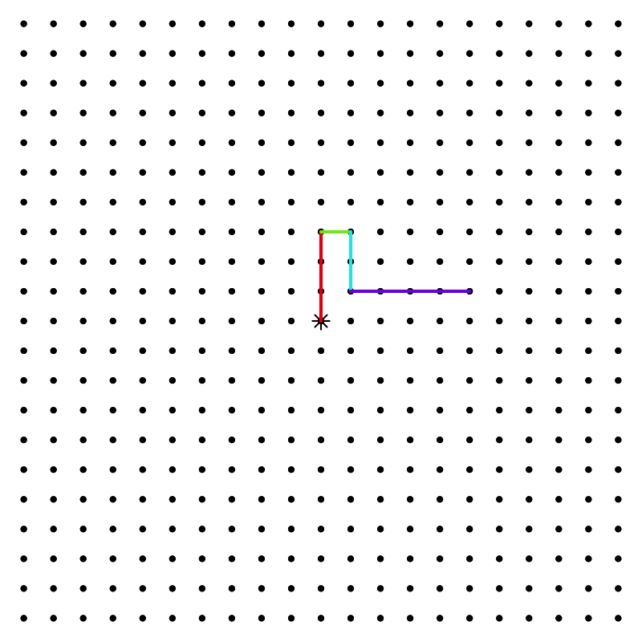

Describe the path taken by the turtle by typing a string of characters.

- Character `F` means go forward 1 unit.
- Character `+` means turn right (clockwise) 90°.
- Character `-` means turn left (counterclockwise) 90°.

Remember to use uppercase `F` and no spaces.

The path could be described as...

- Go 3
- Turn right
- Go 1
- Turn right
- Go 2
- Turn left
- Go 4

So, using those characters...

`FFF+F+FF-FFFF`

A turtle starts at the star in the middle, facing North. While dragging markers, she walks forward for a while, then turns either to her right (clockwise) or to her left (counterclockwise) by 90°. She repeats this, starting with a red marker, until she has drawn 4 segments.

The distance between adjacent dots is 1 unit.

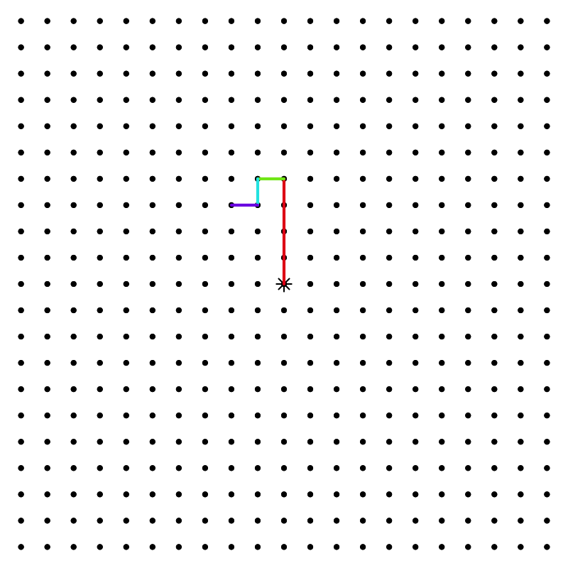

Describe the path taken by the turtle by typing a string of characters.

- Character `F` means go forward 1 unit.
- Character `+` means turn right (clockwise) 90°.
- Character `-` means turn left (counterclockwise) 90°.

Remember to use uppercase `F` and no spaces.

The path could be described as...

- Go 4
- Turn left
- Go 1
- Turn left
- Go 1
- Turn right
- Go 1

So, using those characters...

`FFFF-F-F+F`

A turtle starts at the star in the middle, facing North. While dragging markers, she walks forward for a while, then turns either to her right (clockwise) or to her left (counterclockwise) by 90°. She repeats this, starting with a red marker, until she has drawn 4 segments.

The distance between adjacent dots is 1 unit.

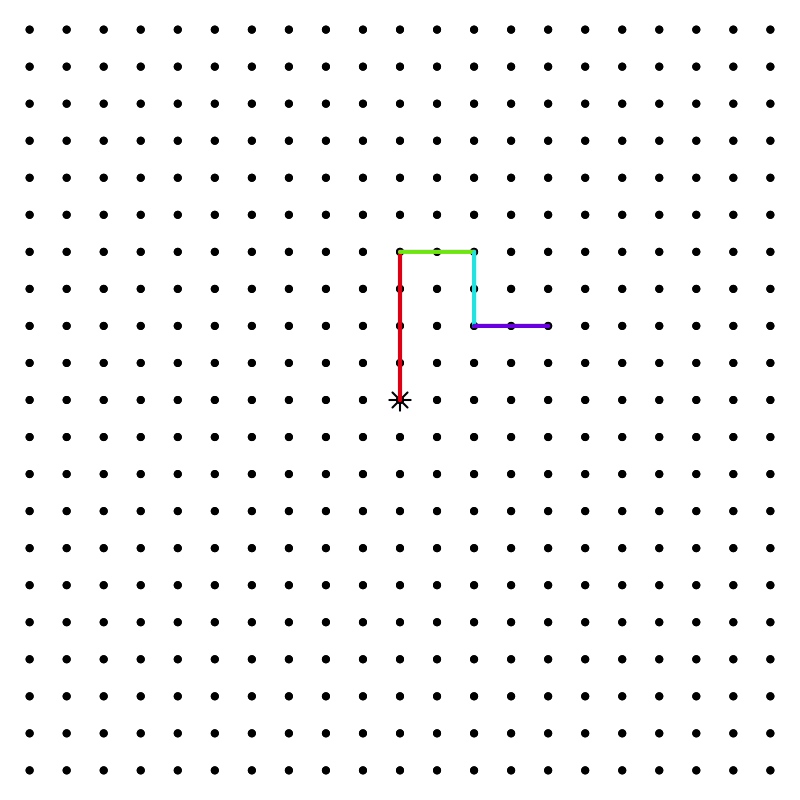

Describe the path taken by the turtle by typing a string of characters.

- Character `F` means go forward 1 unit.
- Character `+` means turn right (clockwise) 90°.
- Character `-` means turn left (counterclockwise) 90°.

Remember to use uppercase `F` and no spaces.

The path could be described as...

- Go 4
- Turn right
- Go 2
- Turn right
- Go 2
- Turn left
- Go 2

So, using those characters...

`FFFF+FF+FF-FF`

A turtle starts at the star in the middle, facing North. While dragging markers, she walks forward for a while, then turns either to her right (clockwise) or to her left (counterclockwise) by 90°. She repeats this, starting with a red marker, until she has drawn 4 segments.

The distance between adjacent dots is 1 unit.

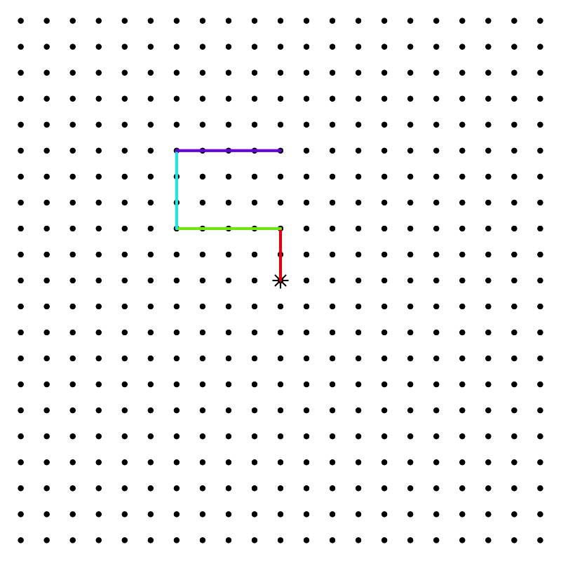

Describe the path taken by the turtle by typing a string of characters.

- Character `F` means go forward 1 unit.
- Character `+` means turn right (clockwise) 90°.
- Character `-` means turn left (counterclockwise) 90°.

Remember to use uppercase `F` and no spaces.

The path could be described as...

- Go 2
- Turn left
- Go 4
- Turn right
- Go 3
- Turn right
- Go 4

So, using those characters...

`FF-FFFF+FFF+FFFF`

A turtle starts at the star in the middle, facing North. While dragging markers, she walks forward for a while, then turns either to her right (clockwise) or to her left (counterclockwise) by 90°. She repeats this, starting with a red marker, until she has drawn 4 segments.

The distance between adjacent dots is 1 unit.

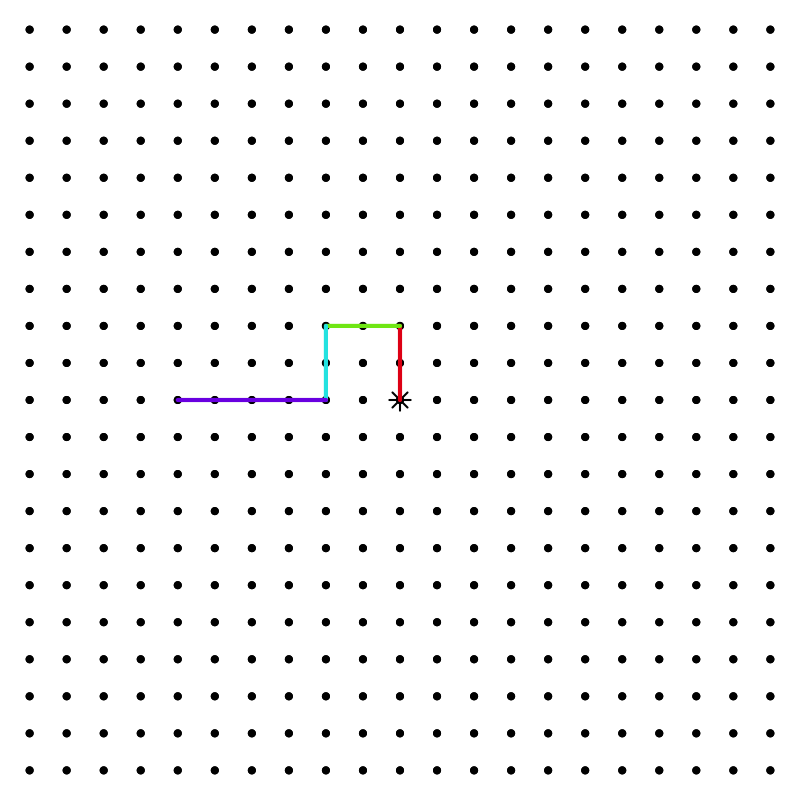

Describe the path taken by the turtle by typing a string of characters.

- Character `F` means go forward 1 unit.
- Character `+` means turn right (clockwise) 90°.
- Character `-` means turn left (counterclockwise) 90°.

Remember to use uppercase `F` and no spaces.

The path could be described as...

- Go 2
- Turn left
- Go 2
- Turn left
- Go 2
- Turn right
- Go 4

So, using those characters...

`FF-FF-FF+FFFF`

A turtle starts at the star in the middle, facing North. While dragging markers, she walks forward for a while, then turns either to her right (clockwise) or to her left (counterclockwise) by 90°. She repeats this, starting with a red marker, until she has drawn 4 segments.

The distance between adjacent dots is 1 unit.

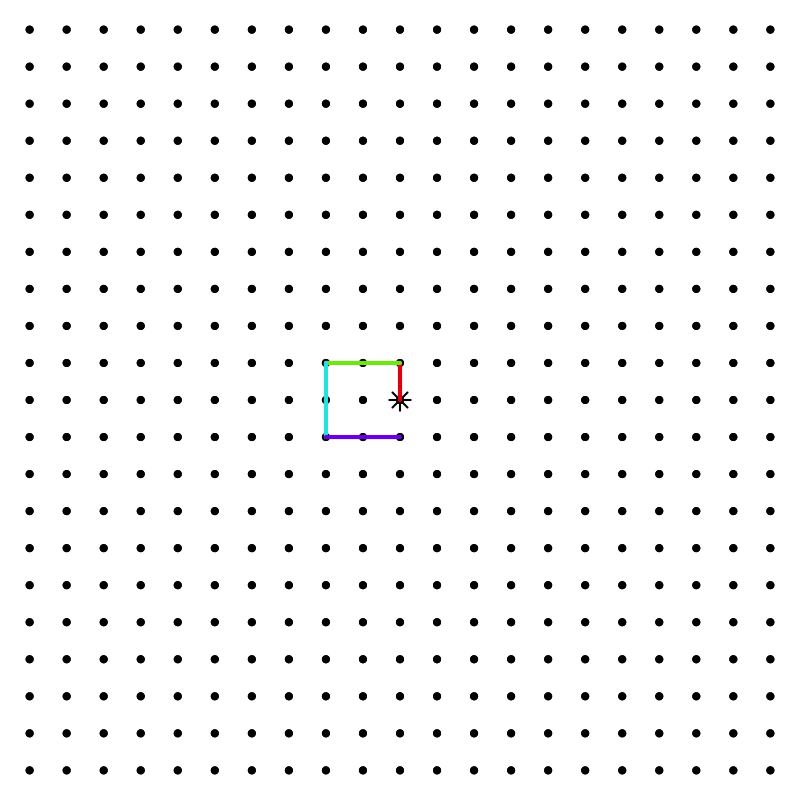

Describe the path taken by the turtle by typing a string of characters.

- Character `F` means go forward 1 unit.
- Character `+` means turn right (clockwise) 90°.
- Character `-` means turn left (counterclockwise) 90°.

Remember to use uppercase `F` and no spaces.

The path could be described as...

- Go 1
- Turn left
- Go 2
- Turn left
- Go 2
- Turn left
- Go 2

So, using those characters...

`F-FF-FF-FF`

A turtle starts at the star in the middle, facing North. While dragging markers, she walks forward for a while, then turns either to her right (clockwise) or to her left (counterclockwise) by 90°. She repeats this, starting with a red marker, until she has drawn 4 segments.

The distance between adjacent dots is 1 unit.

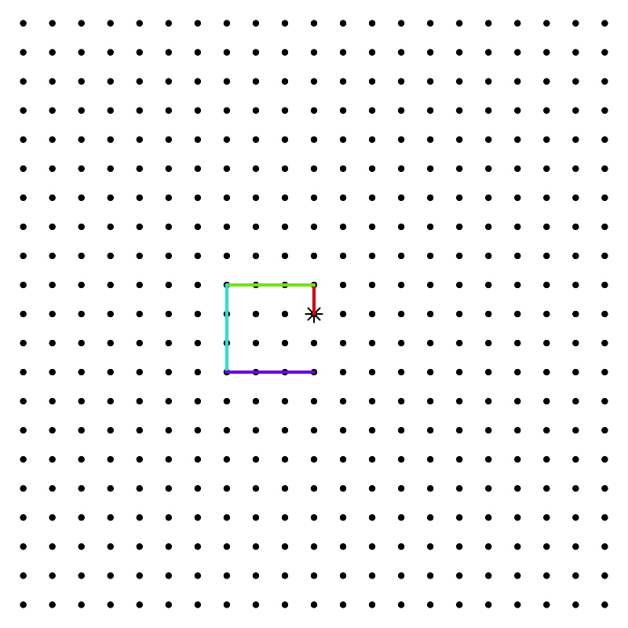

Describe the path taken by the turtle by typing a string of characters.

- Character `F` means go forward 1 unit.
- Character `+` means turn right (clockwise) 90°.
- Character `-` means turn left (counterclockwise) 90°.

Remember to use uppercase `F` and no spaces.

The path could be described as...

- Go 1
- Turn left
- Go 3
- Turn left
- Go 3
- Turn left
- Go 3

So, using those characters...

`F-FFF-FFF-FFF`

A turtle starts at the star in the middle, facing North. While dragging markers, she walks forward for a while, then turns either to her right (clockwise) or to her left (counterclockwise) by 90°. She repeats this, starting with a red marker, until she has drawn 4 segments.

The distance between adjacent dots is 1 unit.

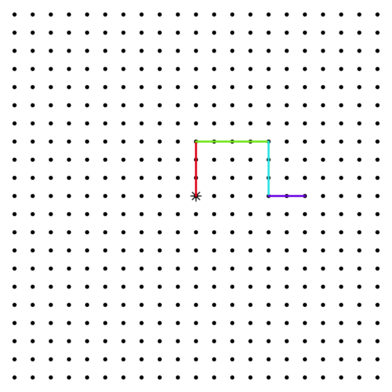

Describe the path taken by the turtle by typing a string of characters.

- Character `F` means go forward 1 unit.
- Character `+` means turn right (clockwise) 90°.
- Character `-` means turn left (counterclockwise) 90°.

Remember to use uppercase `F` and no spaces.

The path could be described as...

- Go 3
- Turn right
- Go 4
- Turn right
- Go 3
- Turn left
- Go 2

So, using those characters...

`FFF+FFFF+FFF-FF`

A turtle starts at the star in the middle, facing North. While dragging markers, she walks forward for a while, then turns either to her right (clockwise) or to her left (counterclockwise) by 90°. She repeats this, starting with a red marker, until she has drawn 4 segments.

The distance between adjacent dots is 1 unit.

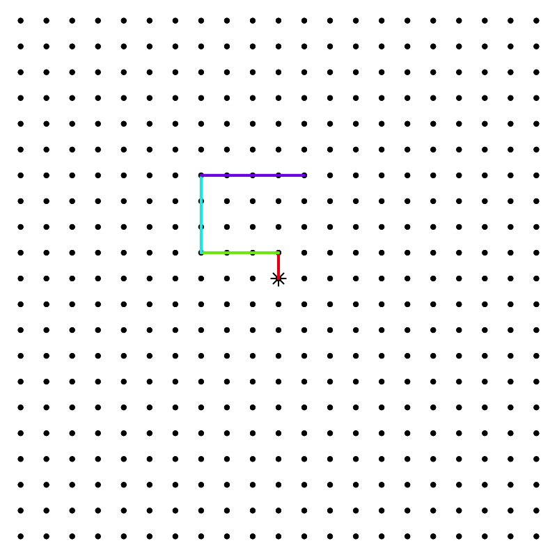

Describe the path taken by the turtle by typing a string of characters.

- Character `F` means go forward 1 unit.
- Character `+` means turn right (clockwise) 90°.
- Character `-` means turn left (counterclockwise) 90°.

Remember to use uppercase `F` and no spaces.

The path could be described as...

- Go 1
- Turn left
- Go 3
- Turn right
- Go 3
- Turn right
- Go 4

So, using those characters...

`F-FFF+FFF+FFFF`